# (Ford GoBike System Data Exploration)

## by: Mohamed Karam

## Investigation Overview

Overall goal is to know how the trip durations may differ among the other features in this dataset such as, user type, age, gender and also the day of the week. By this way and as we go through these valuable features in the dataset, we can explore most of our dataset and identify any possible trends and get some key insights.

## Dataset Overview

This data set includes information about individual rides made in a bike-sharing system covering the greater San Francisco Bay area in the month of February 2019.

## What is the average ride duration?

The average trip duration is between 3 and 13 minutes

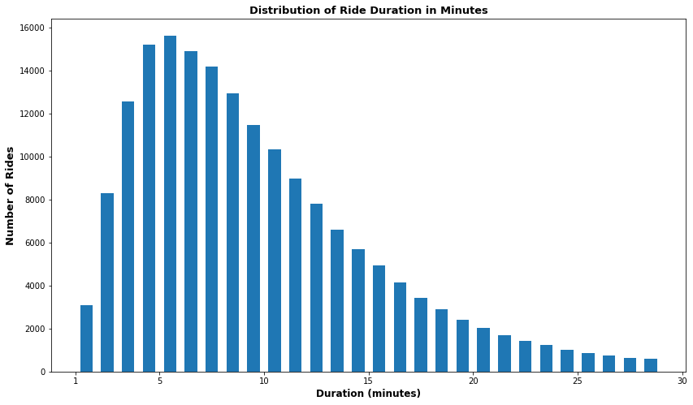

## Which day of the week has the most trips on it?

Most rides seemed to start on **Thursday** for this month of February while **Saturday & Sunday** were the least days of the week in bike rides.

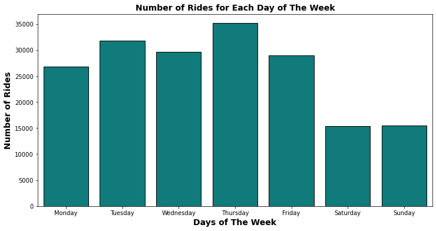

## Which gender has the most bike rides?

Males have significantly more bike rides than females

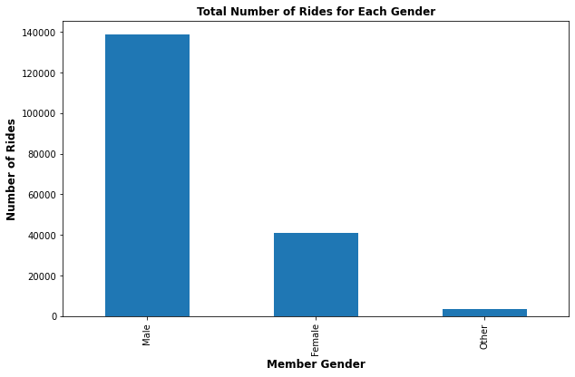

## Which user type has the most rides?

Subscribers are significantly more than customers.

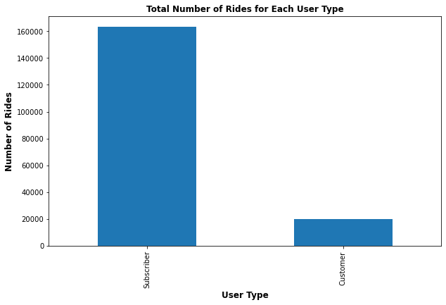

## Which user type has longer trip durations?

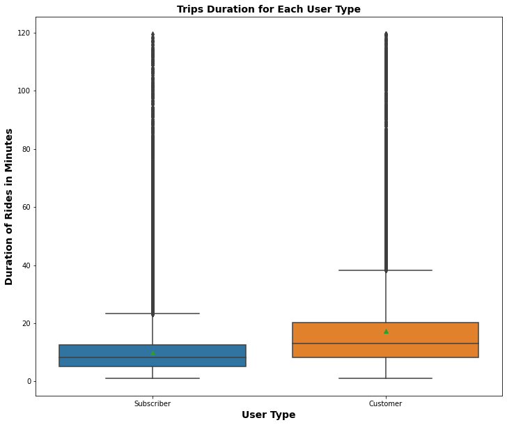

## Which day has the longest duratuion?

(Weekends) **Sunday and Saturday** have the longest duration among the rest weekdays, although they were the least days that have trips as we saw above!

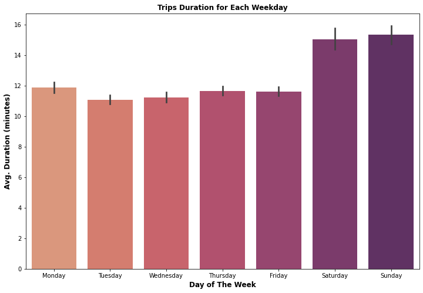

## Do females ride more bikes than males on certain days of the week?

Males take signficantly more bike rides than females every single day of the week. This maybe could be because the number of males in this dataset is notably higher than females.

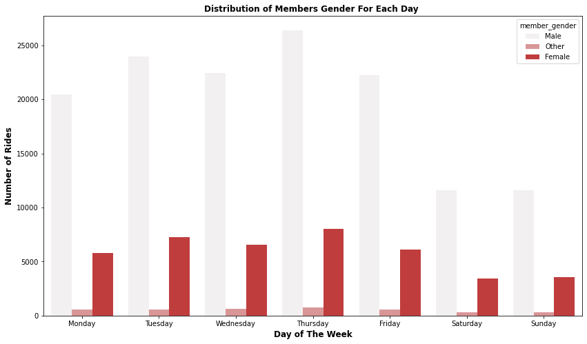

## Do younger users tend to have longer trip durations?

Indeed, more younger members achieve longer trip durations than members older than **60** years old. Under 60 years old the data is somehow evenly distributed.

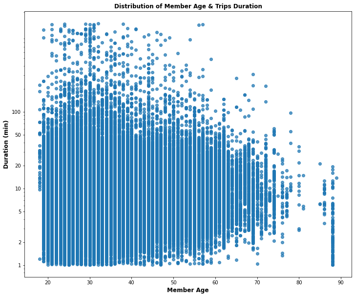

## How trip duration according to user type is distributed on each day?

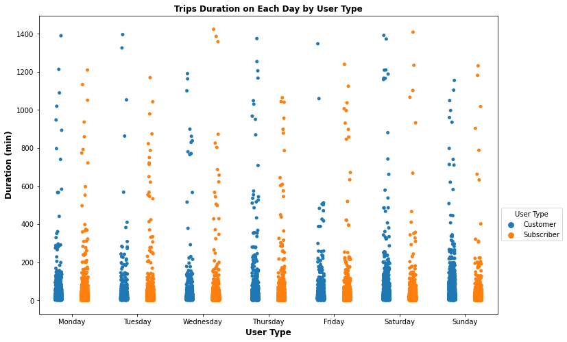